# Ecological Fallacy

## Immigration and Illiteracy

Robinson (1950)

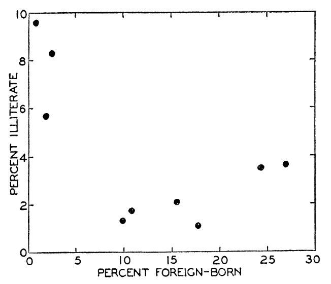

**Suggests foreign-born people tend to be more literate (cor = -0.51).**

## Immigration and Illiteracy

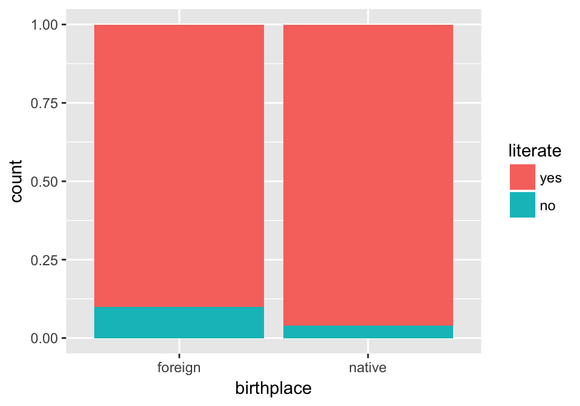

- correlation = 0.11

## What's going on?

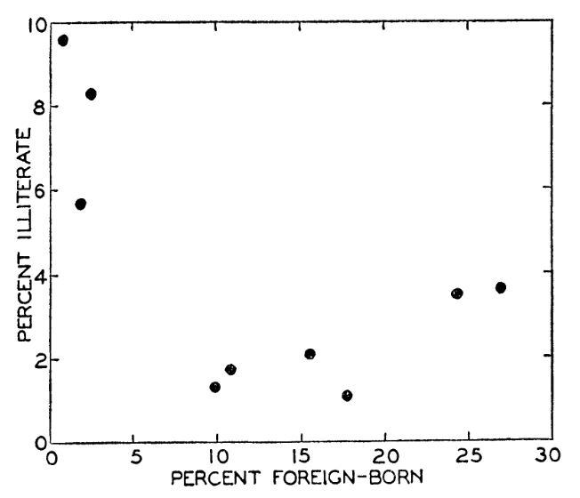

- **Unit of observation**: region (New England, Mountain, Pacific, etc.)
- **Explanation**: regions with many foreign-born have highly literate natives.

## Ecological Fallacy

The false assumption that relationships that exist at an **aggregated level** (e.g. between states, counties, nations) also hold at the **individual level**.

## Immigration and Income

Freedman (1999)

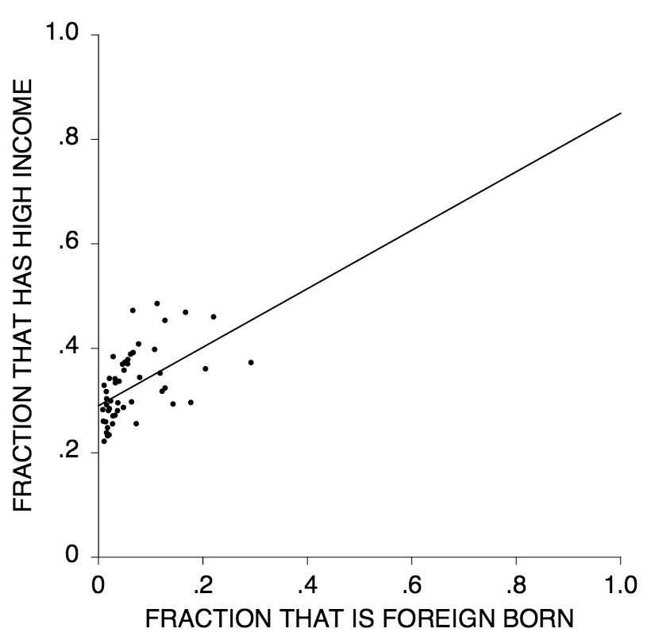

**Suggests that foreign-born populations tend to have higher incomes (corr = 0.52).**

## Immigration and Income

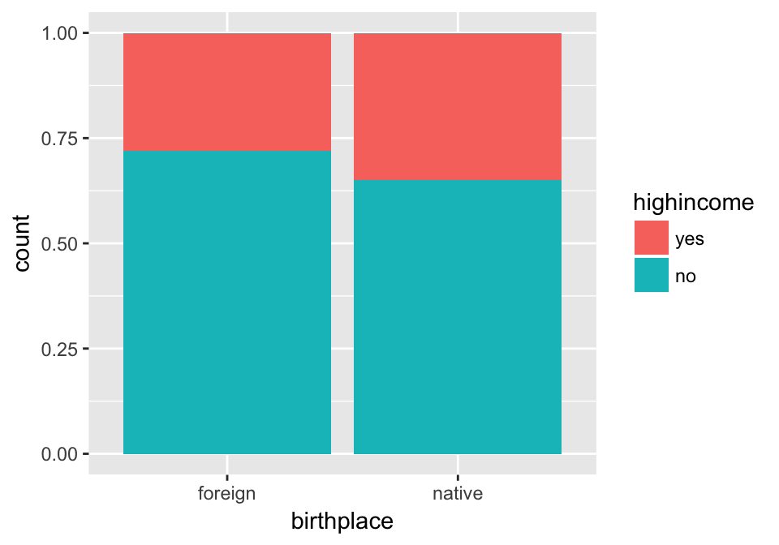

- correlation = -0.05

## What's going on?

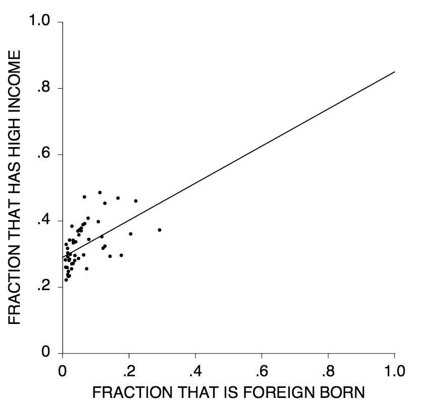

- **Unit of observation**: state
- **Explanation**: states with many foreign-born people have natives with higher incomes.

## Ecological Fallacy

The false assumption that relationships that exist at an **aggregated level** (e.g. between states, counties, nations) also hold at the **individual level**.

Interpretations can invert due to:

- confounding / omitted variable (Model 1)
- aggregation (Model 2)

## Strategies

1. When dealing with an ecological study, restrict model interpretations to the same observational level on which the data was collected.
2. If you want to make individual-level inferences, be sure your data is collected on that same level. Aggregate-level effects can be introduced via a multi-level model.